# Team Information

## Final Project : Comcast vs Public Opinion

## Names and Emails

Gina Catellier - gcatellier@bryant.edu

Kai-Jia Yue - kyue1@bryant.edu

Nathan Angell - nangell@bryant.edu

## Group Number 5: Twitter Thieves

## Team Member Photos

Gina Catellier

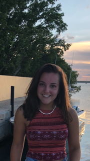

Kai-Jia Yue

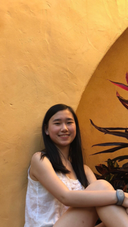

Nathan Angell

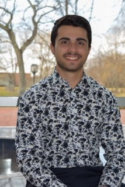

# Abstract

In this project, we decided to look at twitter tweets about Comcast and see if there was a reflection on the stock prices. Our hypothesis is that the Comcast community spirit is dull compared to other companies and their stock price reflects this downfall in this time of financial crisis. Using scrapped data from Twitter, we looked at whether the sentiment of people on twitter would affect the stock prices. We scraped twitter for the tweets about comcast and then made visual plots to see if the stocks could be predicted by the feelings of twitter user.

# Description of the Data

## Scrapers Used

[figure not shown]

We used data that we scrapped from Twitter for a period of 24 weeks using a Twitter scrapper that did not require a Twitter API.

## Data Description

The data we used for this assignment is data we scrapped from Twitter and a financial dataset about Comcast stocks. The twitter data included information such as hashtags, unique identifiers for the tweet, the text of the tweet, the name of the person who tweeted, the username of the person who tweeted, the location of the user, the description in the user's bio, the number of followers, the number of friends, the number of lists, the total number of tweets per user, and the date that the account was made.

## When and How Long Twitter Was Scraped

We scraped Twitter on April 28th and 29th for 4 hours each day. The twitter data dated back to the previous 24 weeks.

## Alternative Data Source(s) Used

The alternative data source that we used is a data set of the financial set for comcast. We also found data on the location of each comcast center.

# EDA

## Importing the Data

```python
!pip install GetOldTweets3
```

```python
import GetOldTweets3 as got
import pandas as pd
```

## Scraping for Tweets Containing 'Comcast'

```python
def username_tweets_to_csv(username, count):
    # Creation of query object
    tweetCriteria = got.manager.TweetCriteria().setUsername(username)\
                                            .setMaxTweets(count)
    # Creation of list that contains all tweets
    tweets = got.manager.TweetManager.getTweets(tweetCriteria)

    # Creating list of chosen tweet data
    user_tweets = [[tweet.date, tweet.text] for tweet in tweets]

    # Creation of dataframe from tweets list
    tweets_df = pd.DataFrame(user_tweets, columns = ['Datetime', 'Text'])

    # Converting dataframe to CSV
    tweets_df.to_csv('{}-{}k-tweets.csv'.format(username, int(count/1000)), sep=',')
```

```python
def text_query_to_csv(text_query, count):
    # Creation of query object
    tweetCriteria = got.manager.TweetCriteria().setQuerySearch(text_query)\
                                                .setMaxTweets(count)
    # Creation of list that contains all tweets
    tweets = got.manager.TweetManager.getTweets(tweetCriteria) # GetOldTweets3.models.Tweet.Tweet object
    # Can access the following aspects of a tweet as instance variables
    #    'author_id', 'date', 'favorites', 'formatted_date', 'geo', 'hashtags', 'id', 'mentions',
    #    'permalink', 'replies', 'retweets', 'text', 'to', 'urls', 'username'

    # switch on debugger by uncommenting the following
    # from IPython.core.debugger import Pdb as pdb;    pdb().set_trace() #breakpoint; dont forget to quit
    # Creating list of chosen tweet data
    text_tweets = [[tweet.date, tweet.text, tweet.hashtags] for tweet in tweets]

    # Creation of dataframe from tweets
    tweets_df = pd.DataFrame(text_tweets, columns = ['Datetime', 'Text', 'hashtags'])

    # Converting tweets dataframe to csv file
    tweets_df.to_csv(f'{"_".join(text_query.split())}_{int(count/1000)}k_tweets.csv')
```

```python
def process_tweet(tweet):
    d = {}
    d['hashtags'] = [hashtag['text'] for hashtag in tweet['entities']['hashtags']]
    d['id'] = tweet['id']
    d['text'] = tweet['text']
    d['name'] = tweet['user']['name']
    d['user'] = tweet['user']['screen_name']
    d['user_loc'] = tweet['user']['location']
    d['user_desc'] = tweet['user']['description']
    d['user_followers'] = tweet['user']['followers_count']
    d['user_friends'] = tweet['user']['friends_count']
    d['user_listed'] = tweet['user']['listed_count']
    d['user_created'] = tweet['user']['created_at']
    d['user_favs'] = tweet['user']['favourites_count']
    d['user_statuses'] = tweet['user']['statuses_count']

    return d

# Function that pulls tweets based on a general search query and turns to csv file

# Parameters: (text query you want to search), (max number of most recent tweets to pull from)
def text_query_to_csv(text_query, count):
    # Creation of query object
    tweetCriteria = got.manager.TweetCriteria().setQuerySearch(text_query)\
                                                .setMaxTweets(count)
    # Creation of list that contains all tweets
    tweets = got.manager.TweetManager.getTweets(tweetCriteria) # GetOldTweets3.models.Tweet.Tweet object
    # Can access the following aspects of a tweet as instance variables
    #    'author_id', 'date', 'favorites', 'formatted_date', 'geo', 'hashtags', 'id', 'mentions',
    #    'permalink', 'replies', 'retweets', 'text', 'to', 'urls', 'username'

    # switch on debugger by uncommenting the following
    # from IPython.core.debugger import Pdb as pdb;    pdb().set_trace() #breakpoint; dont forget to quit
    # Creating list of chosen tweet data
    text_tweets = [[tweet.date, tweet.text, tweet.hashtags] for tweet in tweets]

    # Creation of dataframe from tweets
    tweets_df = pd.DataFrame(text_tweets, columns = ['Datetime', 'Text', 'hashtags'])

    # Converting tweets dataframe to csv file
    tweets_df.to_csv(f'{"_".join(text_query.split())}_{int(count/1000)}k_tweets{start_of_week}.csv', mode = "a")

def get_tweet_vector(tweet):
    got3_columns = ['formatted_date', "author_id",  "username",  "geo", "text", "hashtags", 'mentions',
                "to", "urls",
                'replies', 'retweets',  "favorites", 'permalink']
    return [tweet.hashtags, tweet.author_id, tweet.username, tweet.geo, tweet.text, tweet.hashtags,
     tweet.mentions, tweet.to, tweet.urls, tweet.replies, tweet.retweets, tweet.favorites, tweet.permalink]


def get_tweet_result(text_query = 'comcast', since_date = '2019-11-01',
                     until_date = '2019-04-28', count = 2000):
    # Creation of query object
    tweetCriteria = got.manager.TweetCriteria()\
                               .setQuerySearch(text_query) \
                               .setSince(since_date)\
                               .setUntil(until_date)\
                               .setMaxTweets(count)
    # Creation of list that contains all tweets
    tweets = got.manager.TweetManager.getTweets(tweetCriteria)
    # Creating list of chosen tweet data

    got3_columns = ['formatted_date', "author_id",  "username",  "geo", "text", "hashtags", 'mentions',
                    "to", "urls",
                    'replies', 'retweets',  "favorites", 'permalink']
                         #    'author_id', 'date', 'favorites', 'formatted_date', 'geo', 'hashtags',
                         # 'id', 'mentions',
        #    'permalink', 'replies', 'retweets', 'text', 'to', 'urls', 'username'

    text_tweets = [[tweet.formatted_date, tweet.author_id, tweet.username,
                    tweet.geo, tweet.text, tweet.hashtags,
                    tweet.mentions, tweet.to, tweet.urls, tweet.replies, tweet.retweets,
                    tweet.favorites, tweet.permalink] for tweet in tweets]
    tweets_df = pd.DataFrame(text_tweets, columns=['formatted_date', "author_id",  "username",  "geo", "text", "hashtags", 'mentions',
                    "to", "urls",
                    'replies', 'retweets',  "favorites", 'permalink'])
    filename = f'{"_".join(text_query.split())}_{int(count/1000)}k_tweets{start_of_week}.csv'
    tweets_df.to_csv(filename, mode = "a", header=False, index=False)
    print(filename)
```

```python
import time
from random import seed
from random import randint
# seed random number generator
seed(1)
from datetime import date, datetime, timedelta

def datespan(startDate, endDate, delta=timedelta(days=7)):
    currentDate = startDate
    while currentDate < endDate:
        yield currentDate
        currentDate += delta

text_query = "comcast"
start_of_period = date(2019, 11, 1)
end_of_period   = date(2020, 4, 28)
start_of_week = start_of_period
week_plus_1_start = start_of_period + timedelta(days=7)

# scrape the tweets on weekly basis (timedelta(days=7))
#
for i, week_plus_1_start in enumerate(datespan(week_plus_1_start, end_of_period, delta=timedelta(days=7))):
    print(f"week {i}, start of week: {start_of_week} {week_plus_1_start}")
    get_tweet_result(text_query = text_query, since_date = f"{start_of_week}",
                 until_date = f"{week_plus_1_start}", count = 2000)
    time.sleep(randint(20, 90)) #suspends (waits) execution of the current thread for a given number of seconds

    start_of_week = week_plus_1_start
```

```
week 0, start of week: 2019-11-01 2019-11-08
comcast_2k_tweets2019-11-01.csv
week 1, start of week: 2019-11-08 2019-11-15
comcast_2k_tweets2019-11-08.csv
week 2, start of week: 2019-11-15 2019-11-22
comcast_2k_tweets2019-11-15.csv
week 3, start of week: 2019-11-22 2019-11-29
comcast_2k_tweets2019-11-22.csv
week 4, start of week: 2019-11-29 2019-12-06
comcast_2k_tweets2019-11-29.csv
week 5, start of week: 2019-12-06 2019-12-13
comcast_2k_tweets2019-12-06.csv
week 6, start of week: 2019-12-13 2019-12-20
comcast_2k_tweets2019-12-13.csv
week 7, start of week: 2019-12-20 2019-12-27
comcast_2k_tweets2019-12-20.csv
week 8, start of week: 2019-12-27 2020-01-03
comcast_2k_tweets2019-12-27.csv
week 9, start of week: 2020-01-03 2020-01-10
comcast_2k_tweets2020-01-03.csv
week 10, start of week: 2020-01-10 2020-01-17
comcast_2k_tweets2020-01-10.csv
week 11, start of week: 2020-01-17 2020-01-24
comcast_2k_tweets2020-01-17.csv
week 12, start of week: 2020-01-24 2020-01-31
comcast_2k_tweets2020-01-24.csv
week 13, start of week: 2020-01-31 2020-02-07
comcast_2k_tweets2020-01-31.csv
week 14, start of week: 2020-02-07 2020-02-14
comcast_2k_tweets2020-02-07.csv
week 15, start of week: 2020-02-14 2020-02-21
comcast_2k_tweets2020-02-14.csv
week 16, start of week: 2020-02-21 2020-02-28
comcast_2k_tweets2020-02-21.csv
week 17, start of week: 2020-02-28 2020-03-06
comcast_2k_tweets2020-02-28.csv
week 18, start of week: 2020-03-06 2020-03-13
comcast_2k_tweets2020-03-06.csv
week 19, start of week: 2020-03-13 2020-03-20
comcast_2k_tweets2020-03-13.csv
week 20, start of week: 2020-03-20 2020-03-27
comcast_2k_tweets2020-03-20.csv
week 21, start of week: 2020-03-27 2020-04-03
comcast_2k_tweets2020-03-27.csv
week 22, start of week: 2020-04-03 2020-04-10
comcast_2k_tweets2020-04-03.csv
week 23, start of week: 2020-04-10 2020-04-17
comcast_2k_tweets2020-04-10.csv
week 24, start of week: 2020-04-17 2020-04-24
comcast_2k_tweets2020-04-17.csv
```

```python
df0 = pd.read_csv("comcast_2k_tweets2019-11-01.csv")
df0.columns = ['formatted_date', "author_id",  "username",  "geo", "text", "hashtags", 'mentions',
                    "to", "urls",
                    'replies', 'retweets',  "favorites", 'permalink']
df1 = pd.read_csv("comcast_2k_tweets2019-11-08.csv")
df1.columns = ['formatted_date', "author_id",  "username",  "geo", "text", "hashtags", 'mentions',
                    "to", "urls",
                    'replies', 'retweets',  "favorites", 'permalink']
df2 = pd.read_csv("comcast_2k_tweets2019-11-15.csv")
df2.columns = ['formatted_date', "author_id",  "username",  "geo", "text", "hashtags", 'mentions',
                    "to", "urls",
                    'replies', 'retweets',  "favorites", 'permalink']
df3 = pd.read_csv("comcast_2k_tweets2019-11-22.csv")
df3.columns = ['formatted_date', "author_id",  "username",  "geo", "text", "hashtags", 'mentions',
                    "to", "urls",
                    'replies', 'retweets',  "favorites", 'permalink']
df4 = pd.read_csv("comcast_2k_tweets2019-11-29.csv")
df4.columns = ['formatted_date', "author_id",  "username",  "geo", "text", "hashtags", 'mentions',
                    "to", "urls",
                    'replies', 'retweets',  "favorites", 'permalink']
df5 = pd.read_csv("comcast_2k_tweets2019-12-06.csv")
df5.columns = ['formatted_date', "author_id",  "username",  "geo", "text", "hashtags", 'mentions',
                    "to", "urls",
                    'replies', 'retweets',  "favorites", 'permalink']
df6 = pd.read_csv("comcast_2k_tweets2019-12-13.csv")
df6.columns = ['formatted_date', "author_id",  "username",  "geo", "text", "hashtags", 'mentions',
                    "to", "urls",
                    'replies', 'retweets',  "favorites", 'permalink']
df7 = pd.read_csv("comcast_2k_tweets2019-12-20.csv")
df7.columns = ['formatted_date', "author_id",  "username",  "geo", "text", "hashtags", 'mentions',
                    "to", "urls",
                    'replies', 'retweets',  "favorites", 'permalink']
df8 = pd.read_csv("comcast_2k_tweets2019-12-27.csv")
df8.columns = ['formatted_date', "author_id",  "username",  "geo", "text", "hashtags", 'mentions',
                    "to", "urls",
                    'replies', 'retweets',  "favorites", 'permalink']
df9 = pd.read_csv("comcast_2k_tweets2020-01-03.csv")
df9.columns = ['formatted_date', "author_id",  "username",  "geo", "text", "hashtags", 'mentions',
                    "to", "urls",
                    'replies', 'retweets',  "favorites", 'permalink']
df10 = pd.read_csv("comcast_2k_tweets2020-01-10.csv")
df10.columns = ['formatted_date', "author_id",  "username",  "geo", "text", "hashtags", 'mentions',
                    "to", "urls",
                    'replies', 'retweets',  "favorites", 'permalink']
df11 = pd.read_csv("comcast_2k_tweets2020-01-17.csv")
df11.columns = ['formatted_date', "author_id",  "username",  "geo", "text", "hashtags", 'mentions',
                    "to", "urls",
                    'replies', 'retweets',  "favorites", 'permalink']
df12 = pd.read_csv("comcast_2k_tweets2020-01-24.csv")
df12.columns = ['formatted_date', "author_id",  "username",  "geo", "text", "hashtags", 'mentions',
                    "to", "urls",
                    'replies', 'retweets',  "favorites", 'permalink']
df13 = pd.read_csv("comcast_2k_tweets2020-01-31.csv")
df13.columns = ['formatted_date', "author_id",  "username",  "geo", "text", "hashtags", 'mentions',
                    "to", "urls",
                    'replies', 'retweets',  "favorites", 'permalink']
df14 = pd.read_csv("comcast_2k_tweets2020-02-07.csv")
df14.columns = ['formatted_date', "author_id",  "username",  "geo", "text", "hashtags", 'mentions',
                    "to", "urls",
                    'replies', 'retweets',  "favorites", 'permalink']
df15 = pd.read_csv("comcast_2k_tweets2020-02-14.csv")
df15.columns = ['formatted_date', "author_id",  "username",  "geo", "text", "hashtags", 'mentions',
                    "to", "urls",
                    'replies', 'retweets',  "favorites", 'permalink']
df16 = pd.read_csv("comcast_2k_tweets2020-02-21.csv")
df16.columns = ['formatted_date', "author_id",  "username",  "geo", "text", "hashtags", 'mentions',
                    "to", "urls",
                    'replies', 'retweets',  "favorites", 'permalink']
df17 = pd.read_csv("comcast_2k_tweets2020-02-28.csv")
df17.columns = ['formatted_date', "author_id",  "username",  "geo", "text", "hashtags", 'mentions',
                    "to", "urls",
                    'replies', 'retweets',  "favorites", 'permalink']
df18 = pd.read_csv("comcast_2k_tweets2020-03-06.csv")
df18.columns = ['formatted_date', "author_id",  "username",  "geo", "text", "hashtags", 'mentions',
                    "to", "urls",
                    'replies', 'retweets',  "favorites", 'permalink']
df19 = pd.read_csv("comcast_2k_tweets2020-03-13.csv")
df19.columns = ['formatted_date', "author_id",  "username",  "geo", "text", "hashtags", 'mentions',
                    "to", "urls",
                    'replies', 'retweets',  "favorites", 'permalink']
df20 = pd.read_csv("comcast_2k_tweets2020-03-20.csv")
df20.columns = ['formatted_date', "author_id",  "username",  "geo", "text", "hashtags", 'mentions',
                    "to", "urls",
                    'replies', 'retweets',  "favorites", 'permalink']
df21 = pd.read_csv("comcast_2k_tweets2020-03-27.csv")
df21.columns = ['formatted_date', "author_id",  "username",  "geo", "text", "hashtags", 'mentions',
                    "to", "urls",
                    'replies', 'retweets',  "favorites", 'permalink']
df22 = pd.read_csv("comcast_2k_tweets2020-04-03.csv")
df22.columns = ['formatted_date', "author_id",  "username",  "geo", "text", "hashtags", 'mentions',
                    "to", "urls",
                    'replies', 'retweets',  "favorites", 'permalink']
df23 = pd.read_csv("comcast_2k_tweets2020-04-10.csv")
df23.columns = ['formatted_date', "author_id",  "username",  "geo", "text", "hashtags", 'mentions',
                    "to", "urls",
                    'replies', 'retweets',  "favorites", 'permalink']
df24 = pd.read_csv("comcast_2k_tweets2020-04-17.csv")
df24.columns = ['formatted_date', "author_id",  "username",  "geo", "text", "hashtags", 'mentions',
                    "to", "urls",
                    'replies', 'retweets',  "favorites", 'permalink']
```

```python
comcast_df = df0.append([df1,df2,df3,df4,df5,df6,df7,df8,df9,df10,df11,df12,df13,df14,df15,df16,df17,df18,df19,df20,df21,df22,df23,df24])
```

```python
comcast_df.shape
```

```
(51975, 13)
```

```python
comcast_df = comcast_df.drop_duplicates("text")
```

```python
comcast_df.shape
```

```
(46937, 13)
```

```python
comcast_df.head()
```

|  | formatted_date | author_id | username | geo | text | hashtags | mentions | to | urls | replies | retweets | favorites | permalink |
| --- | --- | --- | --- | --- | --- | --- | --- | --- | --- | --- | --- | --- | --- |
| 0 | Thu Nov 07 23:59:19 +0000 2019 | 349817423 | RichardHall16 | NaN | Comcast wants race to be the overwhelming fact... | NaN | NaN | yarimakarama | NaN | 0 | 0 | 1 | https://twitter.com/RichardHall16/status/11925... |
| 1 | Thu Nov 07 23:58:59 +0000 2019 | 1043349404 | sandyweicher | NaN | Paul D’archangelo and Tony Speller at the Comc... | #ifreakin | @ComcastNewEng | NaN | NaN | 0 | 0 | 9 | https://twitter.com/sandyweicher/status/119259... |
| 2 | Thu Nov 07 23:58:29 +0000 2019 | 23479610 | KatlynRJ24 | NaN | Kyrsten Sinema, the Only Anti-Net Neutrality D... | NaN | @Sludge | NaN | https://readsludge.com/2019/11/07/krysten-sine... | 0 | 0 | 0 | https://twitter.com/KatlynRJ24/status/11925921... |
| 3 | Thu Nov 07 23:58:18 +0000 2019 | 2385236503 | electron2716 | NaN | My @comcast internet has gone out 574 times in... | NaN | @comcast | NaN | NaN | 0 | 0 | 0 | https://twitter.com/electron2716/status/119259... |
| 4 | Thu Nov 07 23:57:44 +0000 2019 | 32971803 | mrstrange71 | NaN | Stay Woke: NYU Law professor breaks down the u... | NaN | NaN | NaN | https://thegrio.com/2019/11/05/melissa-murray-... | 0 | 0 | 0 | https://twitter.com/mrstrange71/status/1192591... |

## Scraping Data for Comcast Tweeting about Itself

```python
username_tweets_to_csv('comcastcares', 2000)
```

```python
self0 = pd.read_csv("comcastcare-2k-tweets.csv")
self0.columns = ['Datetime', 'Text', 'hashtags']
self1 = pd.read_csv("comcastcare-5k-tweets.csv")
self1.columns =['Datetime', 'Text', 'hashtags']
self2 = pd.read_csv("comcastcares-2k-tweets.csv")
self2.columns =['Datetime', 'Text', 'hashtags']
self3 = pd.read_csv("comcastcares-5k-tweets.csv")
self3.columns = ['Datetime', 'Text', 'hashtags']
```

```python
comcast_self_df = self0.append([self1,self2,self3])
comcast_self_df.shape
```

```
(7000, 3)
```

```python
comcast_self_df = comcast_self_df.drop_duplicates("Text")
comcast_self_df.shape
```

```
(5005, 3)
```

## Import Data on Comcast Stock

```python
comcast_stock_df = pd.read_csv("CMCSA.csv")
comcast_stock_df.head()
```

|  | Date | Open | High | Low | Close | Adj Close | Volume |
| --- | --- | --- | --- | --- | --- | --- | --- |
| 0 | Nov-19 | 45.110001 | 45.220001 | 43.529999 | 45.189999 | 44.686069 | 86219400 |
| 1 | Nov-19 | 44.880001 | 45.669998 | 44.430000 | 44.560001 | 44.063095 | 69266500 |
| 2 | Nov-19 | 44.310001 | 44.910000 | 43.779999 | 44.799999 | 44.300415 | 78329700 |
| 3 | Nov-19 | 44.830002 | 44.900002 | 43.250000 | 44.150002 | 43.657669 | 93756100 |
| 4 | Dec-19 | 44.400002 | 44.419998 | 43.080002 | 44.240002 | 43.746666 | 92727600 |

## Imports and Data Cleaning

```python
!pip install wordcloud
!pip install gender_guesser
!pip install TextBlob
import numpy as np
import pandas as pd
#import tweepy
#import twython

import json
import csv
import os
import codecs
import time
import gender_guesser.detector as gender
from textblob import TextBlob
from wordcloud import WordCloud, STOPWORDS
import seaborn as sns
import matplotlib.pyplot as plt
import re
%matplotlib inline
```

## Polarity and Subjectivity Scores

```python
comcast_df['text'] = comcast_df['text'].apply(lambda x: str(x))
comcast_self_df['hashtags'] = comcast_self_df['hashtags'].apply(lambda x: str(x))

comcast_df['PolarityScore'] = comcast_df.text.apply(lambda txt:  TextBlob(txt).polarity)
comcast_self_df['PolarityScore'] = comcast_self_df.hashtags.apply(lambda txt:  TextBlob(txt).polarity)
comcast_df['SubjectivityScore'] = comcast_df.text.apply(lambda txt:  TextBlob(txt).subjectivity)
comcast_self_df['SubjectivityScore'] = comcast_self_df.hashtags.apply(lambda txt:  TextBlob(txt).subjectivity)

comcast_df.head()
```

|  | formatted_date | author_id | username | geo | text | hashtags | mentions | to | urls | replies | retweets | favorites | permalink | PolarityScore | SubjectivityScore |
| --- | --- | --- | --- | --- | --- | --- | --- | --- | --- | --- | --- | --- | --- | --- | --- |
| 0 | Thu Nov 07 23:59:19 +0000 2019 | 349817423 | RichardHall16 | NaN | Comcast wants race to be the overwhelming fact... | NaN | NaN | yarimakarama | NaN | 0 | 0 | 1 | https://twitter.com/RichardHall16/status/11925... | -0.064583 | 0.618750 |
| 1 | Thu Nov 07 23:58:59 +0000 2019 | 1043349404 | sandyweicher | NaN | Paul D’archangelo and Tony Speller at the Comc... | #ifreakin | @ComcastNewEng | NaN | NaN | 0 | 0 | 9 | https://twitter.com/sandyweicher/status/119259... | 0.500000 | 1.000000 |
| 2 | Thu Nov 07 23:58:29 +0000 2019 | 23479610 | KatlynRJ24 | NaN | Kyrsten Sinema, the Only Anti-Net Neutrality D... | NaN | @Sludge | NaN | https://readsludge.com/2019/11/07/krysten-sine... | 0 | 0 | 0 | https://twitter.com/KatlynRJ24/status/11925921... | 0.166667 | 0.833333 |
| 3 | Thu Nov 07 23:58:18 +0000 2019 | 2385236503 | electron2716 | NaN | My @comcast internet has gone out 574 times in... | NaN | @comcast | NaN | NaN | 0 | 0 | 0 | https://twitter.com/electron2716/status/119259... | 0.133333 | 0.263889 |
| 4 | Thu Nov 07 23:57:44 +0000 2019 | 32971803 | mrstrange71 | NaN | Stay Woke: NYU Law professor breaks down the u... | NaN | NaN | NaN | https://thegrio.com/2019/11/05/melissa-murray-... | 0 | 0 | 0 | https://twitter.com/mrstrange71/status/1192591... | -0.155556 | 0.288889 |

```python
comcast_self_df.head()
```

|  | Datetime | Text | hashtags | PolarityScore | SubjectivityScore |
| --- | --- | --- | --- | --- | --- |
| 0 | 0 | 2020-05-01 01:17:31+00:00 | Hi, I appreciate you taking your valuable time... | 0.320000 | 0.620000 |
| 1 | 1 | 2020-05-01 01:17:17+00:00 | Good evening! We are sorry for the speeds you ... | 0.328125 | 0.687500 |
| 2 | 2 | 2020-05-01 01:02:53+00:00 | Greetings! I can help with any speed issues yo... | 0.000000 | 0.000000 |
| 3 | 3 | 2020-05-01 00:59:39+00:00 | Thank you for reaching out to Xfinity. May I a... | 0.000000 | 0.466667 |
| 4 | 4 | 2020-05-01 00:58:19+00:00 | Good evening, we truly apologize for the wait ... | 0.412500 | 0.562500 |

## Sentiment Bins

```python
def sentiment_bins(data):
    if data <= -0.5:
        grouping = 'Strong-Negative'
    elif data > -0.5 and data < 0.0:
        grouping = 'Mild-Negative'
    elif data > 0.0 and data < 0.5:
        grouping = 'Mild Positive'
    elif data >=0.5:
        grouping = 'Strong-Positive'
    else:
        grouping = 'Neutral'
    return grouping

comcast_df['sentimentLabel'] = comcast_df['PolarityScore'].apply(sentiment_bins)
comcast_self_df['sentimentLabel'] = comcast_self_df['PolarityScore'].apply(sentiment_bins)

print('Comcast:')
print(comcast_df.describe([0,.25,.50,.75,.90,.99,1]).round(3))

print('Comcast Self:')
print(comcast_self_df.describe([0,.25,.50,.75,.90,.99,1]).round(3))
```

```
Comcast:
          author_id  geo    replies   retweets  favorites  PolarityScore  \
count  4.693700e+04  0.0  46937.000  46937.000  46937.000      46937.000
mean   2.701174e+17  NaN      0.558      1.099      4.349          0.050
std    4.501638e+17  NaN      4.012     38.227    106.870          0.277
min    5.440000e+02  NaN      0.000      0.000      0.000         -1.000
0%     5.440000e+02  NaN      0.000      0.000      0.000         -1.000
25%    8.746071e+07  NaN      0.000      0.000      0.000          0.000
50%    5.350790e+08  NaN      0.000      0.000      0.000          0.000
75%    7.435851e+17  NaN      1.000      0.000      1.000          0.175
90%    1.089572e+18  NaN      1.000      1.000      4.000          0.400
99%    1.225423e+18  NaN      5.000     10.000     49.000          0.800
100%   1.253336e+18  NaN    433.000   6817.000  19618.000          1.000
max    1.253336e+18  NaN    433.000   6817.000  19618.000          1.000

       SubjectivityScore
count          46937.000
mean               0.357
std                0.308
min                0.000
0%                 0.000
25%                0.000
50%                0.371
75%                0.583
90%                0.800
99%                1.000
100%               1.000
max                1.000
Comcast Self:
       PolarityScore  SubjectivityScore
count       5005.000           5005.000
mean           0.231              0.526
std            0.268              0.241
min           -1.000              0.000
0%            -1.000              0.000
25%            0.066              0.400
50%            0.239              0.550
75%            0.388              0.675
90%            0.531              0.800
99%            0.875              1.000
100%           1.000              1.000
max            1.000              1.000
```

## Location Frequency

```python
print(comcast_df.geo.value_counts(dropna = True))
```

```
Series([], Name: geo, dtype: int64)
```

```python
comcast_df = comcast_df.drop(columns=['geo'])
```

We cannot make a geoplot as none of these tweets include location :(

So, we will import data on each location that comcast has a center:

```python
import pandas as pd

comcast_centers_df = pd.read_excel("comcastcenters.xlsx")
comcast_centers_df.columns = ['Location']
comcast_centers_df.head()
```

|  | Location |
| --- | --- |
| 0 | Florence, AL |
| 1 | Gadsden, AL |
| 2 | Huntsville, AL |
| 3 | Madison, AL |
| 4 | Mobile, AL |

# Tweet Importance Metric

```python
def importance_score(data):
    '''Importance of tweets is calculated here based on the amount of favorites that the tweet
    received. The numbers were calculated based on the statistics for the apple twitter data file.
    The number of followers is not taken into account.'''

    if data == 0:
        grouping = '1'
    elif data > 0 and data <= 1:
        grouping = '2'
    elif data > 1 and data <= 4:
        grouping = '3'
    elif data > 4 and data <= 49:
        grouping = '4'
    else:
        grouping = '5'
    return grouping

comcast_df['importanceLabel'] = comcast_df['favorites'].apply(importance_score)
```

```python
comcast_df.head()
```

|  | formatted_date | author_id | username | text | hashtags | mentions | to | urls | replies | retweets | favorites | permalink | PolarityScore | SubjectivityScore | sentimentLabel | importanceLabel |
| --- | --- | --- | --- | --- | --- | --- | --- | --- | --- | --- | --- | --- | --- | --- | --- | --- |
| 0 | Thu Nov 07 23:59:19 +0000 2019 | 349817423 | RichardHall16 | Comcast wants race to be the overwhelming fact... | NaN | NaN | yarimakarama | NaN | 0 | 0 | 1 | https://twitter.com/RichardHall16/status/11925... | -0.064583 | 0.618750 | Mild-Negative | 2 |
| 1 | Thu Nov 07 23:58:59 +0000 2019 | 1043349404 | sandyweicher | Paul D’archangelo and Tony Speller at the Comc... | #ifreakin | @ComcastNewEng | NaN | NaN | 0 | 0 | 9 | https://twitter.com/sandyweicher/status/119259... | 0.500000 | 1.000000 | Strong-Positive | 4 |
| 2 | Thu Nov 07 23:58:29 +0000 2019 | 23479610 | KatlynRJ24 | Kyrsten Sinema, the Only Anti-Net Neutrality D... | NaN | @Sludge | NaN | https://readsludge.com/2019/11/07/krysten-sine... | 0 | 0 | 0 | https://twitter.com/KatlynRJ24/status/11925921... | 0.166667 | 0.833333 | Mild Positive | 1 |
| 3 | Thu Nov 07 23:58:18 +0000 2019 | 2385236503 | electron2716 | My @comcast internet has gone out 574 times in... | NaN | @comcast | NaN | NaN | 0 | 0 | 0 | https://twitter.com/electron2716/status/119259... | 0.133333 | 0.263889 | Mild Positive | 1 |
| 4 | Thu Nov 07 23:57:44 +0000 2019 | 32971803 | mrstrange71 | Stay Woke: NYU Law professor breaks down the u... | NaN | NaN | NaN | https://thegrio.com/2019/11/05/melissa-murray-... | 0 | 0 | 0 | https://twitter.com/mrstrange71/status/1192591... | -0.155556 | 0.288889 | Mild-Negative | 1 |

# Visual EDA

## Creating a Geoplot

```python
!pip install geopandas
!pip install geopy
```

[output not shown]

```python
from geopy.geocoders import Nominatim
locator = Nominatim(user_agent="myGeocoder")
coordinates_list = []
for x in comcast_centers_df['Location']:
    try:
        location = locator.geocode(x)
        coordinates_list.append(location)
    except:
        pass
```

```python
for x in coordinates_list:
    if x == None:
        coordinates_list.remove(x)
coordinates_list = pd.DataFrame(coordinates_list)
coordinates_list.shape
```

```
(499, 2)
```

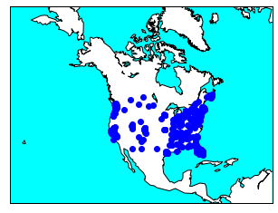

```python
import mpl_toolkits
mpl_toolkits.__path__.append('/usr/lib/python2.7/dist-packages/mpl_toolkits/')
from mpl_toolkits.basemap import Basemap
map_plotter = Basemap()
m = Basemap(width=12000000,height=9000000,projection='lcc', resolution='c',lat_1=45.,lat_2=55,lat_0=50,lon_0=-107.)
m.drawcoastlines()
m.drawmapboundary(fill_color='aqua')
m.fillcontinents(color='white',lake_color='aqua')
for row in coordinates_list[1]:
    xpt,ypt = m(row[1],row[0])
    m.plot(xpt,ypt,'bo')
```

This geoplot shows that a majority of comcast business is done on the east coast.

## Correlation Matrix

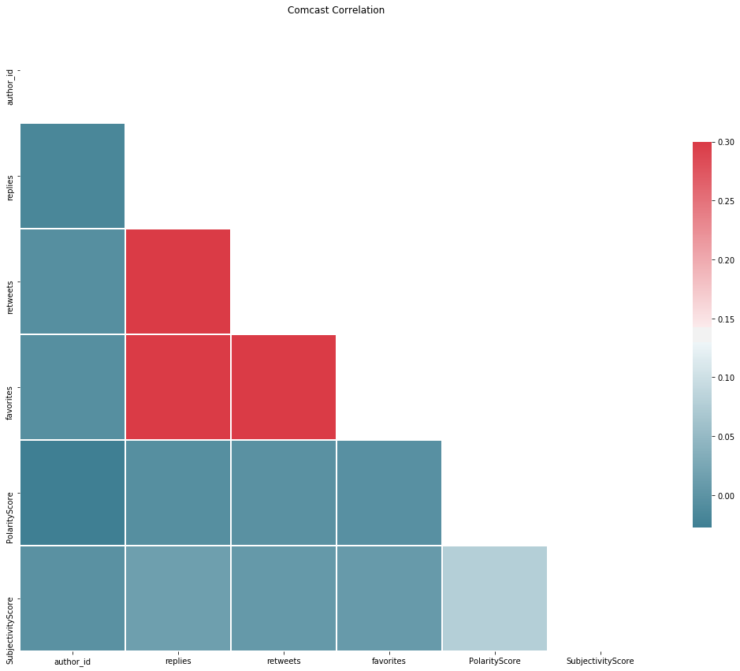

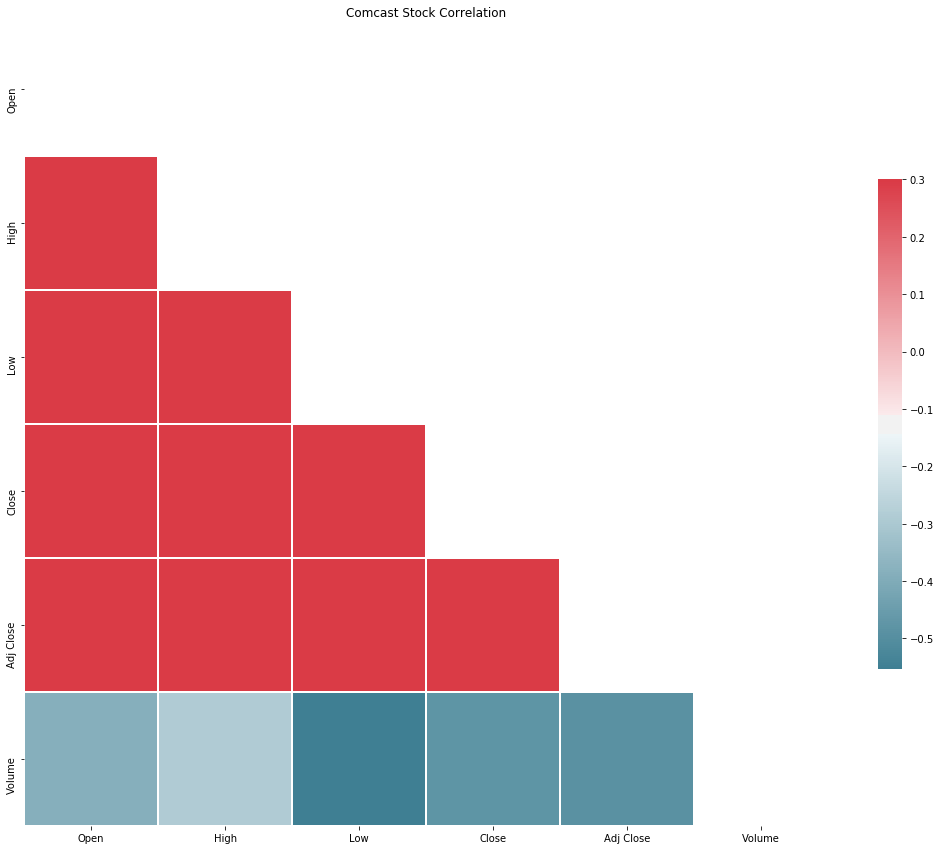

```python
comcast_corr = comcast_df.corr()
comcast_stock_corr = comcast_stock_df.corr()

comcast_mask = np.zeros_like(comcast_corr, dtype=np.bool)
comcast_mask[np.triu_indices_from(comcast_mask)] = True

comcast_stock_mask = np.zeros_like(comcast_stock_corr, dtype=np.bool)
comcast_stock_mask[np.triu_indices_from(comcast_stock_mask)] = True

f, ax = plt.subplots(figsize=(18, 18))
cmap = sns.diverging_palette(220, 10, as_cmap=True)
sns.heatmap(comcast_corr, mask=comcast_mask, cmap=cmap, vmax=.3,
            square=True,
            linewidths=.5, cbar_kws={"shrink": .5}, ax=ax)
ax.set_title('Comcast Correlation')

f, ax = plt.subplots(figsize=(18, 18))
cmap = sns.diverging_palette(220, 10, as_cmap=True)
sns.heatmap(comcast_stock_corr, mask=comcast_stock_mask, cmap=cmap, vmax=.3,
            square=True,
            linewidths=.5, cbar_kws={"shrink": .5}, ax=ax)
ax.set_title('Comcast Stock Correlation')
```

## Sentiment by Importance

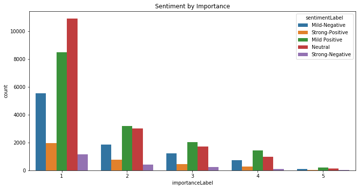

```python
fig, ax = plt.subplots(figsize = (12,6))
sns.countplot(x="importanceLabel", hue="sentimentLabel", data=comcast_df, ax=ax)
ax.set_title('Sentiment by Importance')
```

## Stock vs Polarity Scatterplot

```python
import re
comcast_df['new_date'] = comcast_df['formatted_date'].apply(lambda x : re.findall('(Nov|Dec|Jan|Feb|Mar|Apr)+\s+(\d+)', x)[0][0])
comcast_df['new_date'] = comcast_df['new_date'].apply(lambda x : str(x))
```

```python
comcast_stock_df['new_date'] = comcast_stock_df['Date'].apply(lambda x : re.findall('(Nov|Dec|Jan|Feb|Mar|Apr)', x)[0])
comcast_stock_df['new_date'] = comcast_stock_df['new_date'].apply(lambda x : str(x))
```

```python
small_comcast_df = comcast_df[comcast_df['importanceLabel'] == '5']
small_comcast_df.shape
```

```
(468, 17)
```

```python
nov_importantviews = small_comcast_df[small_comcast_df['new_date'] == 'Nov']
print(nov_importantviews['PolarityScore'].mean())
dec_importantviews = small_comcast_df[small_comcast_df['new_date'] == 'Dec']
print(dec_importantviews['PolarityScore'].mean())
jan_importantviews = small_comcast_df[small_comcast_df['new_date'] == 'Jan']
print(jan_importantviews['PolarityScore'].mean())
feb_importantviews = small_comcast_df[small_comcast_df['new_date'] == 'Feb']
print(feb_importantviews['PolarityScore'].mean())
mar_importantviews = small_comcast_df[small_comcast_df['new_date'] == 'Mar']
print(mar_importantviews['PolarityScore'].mean())
apr_importantviews = small_comcast_df[small_comcast_df['new_date'] == 'Apr']
print(apr_importantviews['PolarityScore'].mean())
```

```
0.09543382431886897
0.05921382189239334
0.03346396591014986
0.026468551014681974
0.07328314569629504
0.07107924482924484
```

The average of the polarity scores for each month does not show a trend in either direction.

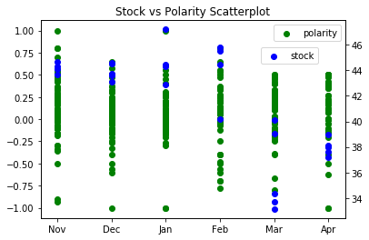

```python
import matplotlib.pyplot as plt
fig,ax=plt.subplots()
ax.scatter('new_date', 'PolarityScore', data=small_comcast_df, color='green', label= 'polarity')
plt.title('Stock vs Polarity Scatterplot')
ax.legend()

ax2=ax.twinx()
ax2.scatter('new_date', 'Adj Close', data=comcast_stock_df, color='blue', label = 'stock')
ax2.legend(loc='upper right', borderaxespad=3)

plt.show()
```

# Results

Our hypothesis that the Comcast community spirit is dull and their stock price reflects this downfall was not shown through the data analysis we did on the tweets we scraped from Twitter and the stock prices that we got from yahoo finance.

None of the visuals that we have made can be used to prove our hypothesis, which leads us to conclude that our hypothesis is incorrect.

# Conclusion

Based on the geoplot that we created, any conclusion that we get from this data can only be applied to the eastern side of the United States. This is the area where the majority of comcast centers operate in. According to our correlation matrix, the most highly correlated variablse are the number of favorites, retweets, and replies. This makes sense, as the more that a tweet is favorites or retweeted, the more people will see it and reply to it. This shows that our importance metric did not need other factors, as the other columns that we had considered using were most correlated with favorites, which is what we did end up using. We also made a correlation matrix on the comcast stock data, but the correlation seemed to be the same for every column except volume, so we were not able to make a conclusion based off of this.